# STEPS OF PROJECT

1.DATA READING 2.EXPLORATORY DATA ANALYSIS AND DATA CLEANING 3.DATA VISUALIZATION 4.SPLITING THE DATA IN TRAINING AND TESTING SETS 5.ASSESSING MULTIPLE ALGORITHMS 6.DRAWING CONCLUSION -SUMMARYIMPORTING IMPORTANT LIBRARIES

```python
import numpy as np
import pandas as pd
import matplotlib.pyplot as plt
import seaborn as sns
```

DATA READING

```python
df = pd.read_csv('Telco-Customer-Churn.csv')
df.head()
```

|  | customerID | gender | SeniorCitizen | Partner | Dependents | tenure | PhoneService | MultipleLines | InternetService | OnlineSecurity | ... | DeviceProtection | TechSupport | StreamingTV | StreamingMovies | Contract | PaperlessBilling | PaymentMethod | MonthlyCharges | TotalCharges | Churn |
| --- | --- | --- | --- | --- | --- | --- | --- | --- | --- | --- | --- | --- | --- | --- | --- | --- | --- | --- | --- | --- | --- |
| 0 | 7590-VHVEG | Female | 0 | Yes | No | 1 | No | No phone service | DSL | No | ... | No | No | No | No | Month-to-month | Yes | Electronic check | 29.85 | 29.85 | No |
| 1 | 5575-GNVDE | Male | 0 | No | No | 34 | Yes | No | DSL | Yes | ... | Yes | No | No | No | One year | No | Mailed check | 56.95 | 1889.50 | No |
| 2 | 3668-QPYBK | Male | 0 | No | No | 2 | Yes | No | DSL | Yes | ... | No | No | No | No | Month-to-month | Yes | Mailed check | 53.85 | 108.15 | Yes |
| 3 | 7795-CFOCW | Male | 0 | No | No | 45 | No | No phone service | DSL | Yes | ... | Yes | Yes | No | No | One year | No | Bank transfer (automatic) | 42.30 | 1840.75 | No |
| 4 | 9237-HQITU | Female | 0 | No | No | 2 | Yes | No | Fiber optic | No | ... | No | No | No | No | Month-to-month | Yes | Electronic check | 70.70 | 151.65 | Yes |

5 rows × 21 columns

VISULISATION OF COLUMAN NAMES

```python
df.columns
```

```
Index(['customerID', 'gender', 'SeniorCitizen', 'Partner', 'Dependents',
       'tenure', 'PhoneService', 'MultipleLines', 'InternetService',
       'OnlineSecurity', 'OnlineBackup', 'DeviceProtection', 'TechSupport',
       'StreamingTV', 'StreamingMovies', 'Contract', 'PaperlessBilling',
       'PaymentMethod', 'MonthlyCharges', 'TotalCharges', 'Churn'],
      dtype='object')
```

CEHECK UNIQUE VALUES OF EACH COLUMNS

```python
for column in df.columns:
    print('column: {} - unique values {}:'.format(column,df[column].unique()))
```

```
column: customerID - unique values ['7590-VHVEG' '5575-GNVDE' '3668-QPYBK' ... '4801-JZAZL' '8361-LTMKD'
 '3186-AJIEK']:
column: gender - unique values ['Female' 'Male']:
column: SeniorCitizen - unique values [0 1]:
column: Partner - unique values ['Yes' 'No']:
column: Dependents - unique values ['No' 'Yes']:
column: tenure - unique values [ 1 34  2 45  8 22 10 28 62 13 16 58 49 25 69 52 71 21 12 30 47 72 17 27
  5 46 11 70 63 43 15 60 18 66  9  3 31 50 64 56  7 42 35 48 29 65 38 68
 32 55 37 36 41  6  4 33 67 23 57 61 14 20 53 40 59 24 44 19 54 51 26 39]:
column: PhoneService - unique values ['No' 'Yes']:
column: MultipleLines - unique values ['No phone service' 'No' 'Yes']:
column: InternetService - unique values ['DSL' 'Fiber optic' 'No']:
column: OnlineSecurity - unique values ['No' 'Yes' 'No internet service']:
column: OnlineBackup - unique values ['Yes' 'No' 'No internet service']:
column: DeviceProtection - unique values ['No' 'Yes' 'No internet service']:
column: TechSupport - unique values ['No' 'Yes' 'No internet service']:
column: StreamingTV - unique values ['No' 'Yes' 'No internet service']:
column: StreamingMovies - unique values ['No' 'Yes' 'No internet service']:
column: Contract - unique values ['Month-to-month' 'One year' 'Two year']:
column: PaperlessBilling - unique values ['Yes' 'No']:
column: PaymentMethod - unique values ['Electronic check' 'Mailed check' 'Bank transfer (automatic)'
 'Credit card (automatic)']:
column: MonthlyCharges - unique values [29.85 56.95 53.85 ... 63.1  44.2  78.7 ]:
column: TotalCharges - unique values [  29.85 1889.5   108.15 ...  346.45  306.6  6844.5 ]:
column: Churn - unique values ['No' 'Yes']:
```

As shown above, the data set contains 19 independent variables, which can be classified into 3 groups: (1) Demographic Information gender: Whether the client is a female or a male (Female, Male). SeniorCitizen: Whether the client is a senior citizen or not ( 0, 1). Partner: Whether the client has a partner or not (Yes, No). Dependents: Whether the client has dependents or not (Yes, No). (2) Customer Account Information tenure: Number of months the customer has stayed with the company (Multiple different numeric values). Contract: Indicates the customer’s current contract type (Month-to-Month, One year, Two year). PaperlessBilling: Whether the client has paperless billing or not (Yes, No). PaymentMethod: The customer’s payment method (Electronic check, Mailed check, Bank transfer (automatic), Credit Card (automatic)). MontlyCharges: The amount charged to the customer monthly (Multiple different numeric values). TotalCharges: The total amount charged to the customer (Multiple different numeric values). (3) Services Information PhoneService: Whether the client has a phone service or not (Yes, No). MultipleLines: Whether the client has multiple lines or not (No phone service, No, Yes). InternetServices: Whether the client is subscribed to Internet service with the company (DSL, Fiber optic, No) OnlineSecurity: Whether the client has online security or not (No internet service, No, Yes). OnlineBackup: Whether the client has online backup or not (No internet service, No, Yes). DeviceProtection: Whether the client has device protection or not (No internet service, No, Yes). TechSupport: Whether the client has tech support or not (No internet service, No, Yes). StreamingTV: Whether the client has streaming TV or not (No internet service, No, Yes). StreamingMovies: Whether the client has streaming movies or not (No internet service, No, Yes).

### EXPLORATORY DATA ANALYSIS AND DATA CLEANING

FINDING MISSING VALUES

```python
df.info()
```

```
<class 'pandas.core.frame.DataFrame'>
RangeIndex: 7032 entries, 0 to 7031
Data columns (total 21 columns):
 #   Column            Non-Null Count  Dtype
---  ------            --------------  -----
 0   customerID        7032 non-null   object
 1   gender            7032 non-null   object
 2   SeniorCitizen     7032 non-null   int64
 3   Partner           7032 non-null   object
 4   Dependents        7032 non-null   object
 5   tenure            7032 non-null   int64
 6   PhoneService      7032 non-null   object
 7   MultipleLines     7032 non-null   object
 8   InternetService   7032 non-null   object
 9   OnlineSecurity    7032 non-null   object
 10  OnlineBackup      7032 non-null   object
 11  DeviceProtection  7032 non-null   object
 12  TechSupport       7032 non-null   object
 13  StreamingTV       7032 non-null   object
 14  StreamingMovies   7032 non-null   object
 15  Contract          7032 non-null   object
 16  PaperlessBilling  7032 non-null   object
 17  PaymentMethod     7032 non-null   object
 18  MonthlyCharges    7032 non-null   float64
 19  TotalCharges      7032 non-null   float64
 20  Churn             7032 non-null   object
dtypes: float64(2), int64(2), object(17)
memory usage: 1.1+ MB
```

THERE IS NO NULL VALUES IN THE DATA SETTHERE IS NO USE OF CUSTEMER ID COLUMN IN MODEL TRAINING SO WE CAN DROP IT

```python
# df =df.drop(columns='customerID', inplace=True)
```

### DATA VISULISATION

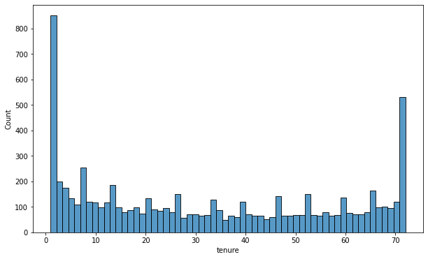

```python
plt.figure(figsize = (10,6))
sns.histplot(data = df,x = 'tenure',bins = 60)
```

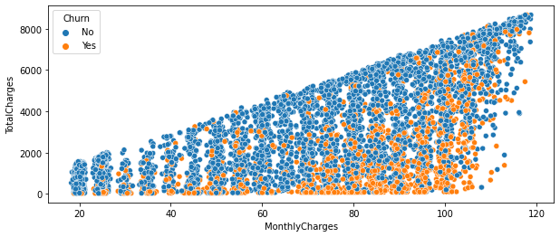

```python
plt.figure(figsize=(10,4))
sns.scatterplot(data= df,x = 'MonthlyCharges',y ='TotalCharges',hue = 'Churn')
```

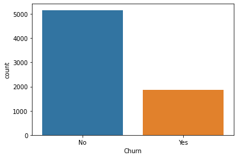

```python
sns.countplot(data = df ,x = 'Churn')
```

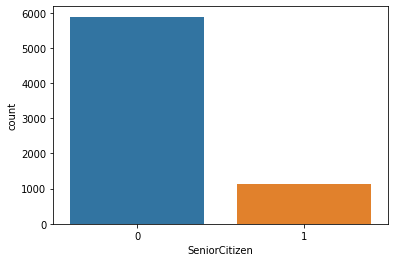

```python
sns.countplot(data = df ,x = 'SeniorCitizen')
```

CONVERT CATEGORICAL DATA INTO NUMBER : with the help of get_dummies comand

```python
df =pd.get_dummies(df[['gender', 'Partner', 'Dependents',
        'PhoneService', 'MultipleLines', 'InternetService',
       'OnlineSecurity', 'OnlineBackup', 'DeviceProtection', 'TechSupport',
       'StreamingTV', 'StreamingMovies', 'Contract', 'PaperlessBilling',
       'PaymentMethod', 'MonthlyCharges', 'TotalCharges', 'Churn']],drop_first=True)
```

```python
df
```

|  | MonthlyCharges | TotalCharges | gender_Male | Partner_Yes | Dependents_Yes | PhoneService_Yes | MultipleLines_No phone service | MultipleLines_Yes | InternetService_Fiber optic | InternetService_No | ... | StreamingTV_Yes | StreamingMovies_No internet service | StreamingMovies_Yes | Contract_One year | Contract_Two year | PaperlessBilling_Yes | PaymentMethod_Credit card (automatic) | PaymentMethod_Electronic check | PaymentMethod_Mailed check | Churn_Yes |
| --- | --- | --- | --- | --- | --- | --- | --- | --- | --- | --- | --- | --- | --- | --- | --- | --- | --- | --- | --- | --- | --- |
| 0 | 29.85 | 29.85 | 0 | 1 | 0 | 0 | 1 | 0 | 0 | 0 | ... | 0 | 0 | 0 | 0 | 0 | 1 | 0 | 1 | 0 | 0 |
| 1 | 56.95 | 1889.50 | 1 | 0 | 0 | 1 | 0 | 0 | 0 | 0 | ... | 0 | 0 | 0 | 1 | 0 | 0 | 0 | 0 | 1 | 0 |
| 2 | 53.85 | 108.15 | 1 | 0 | 0 | 1 | 0 | 0 | 0 | 0 | ... | 0 | 0 | 0 | 0 | 0 | 1 | 0 | 0 | 1 | 1 |
| 3 | 42.30 | 1840.75 | 1 | 0 | 0 | 0 | 1 | 0 | 0 | 0 | ... | 0 | 0 | 0 | 1 | 0 | 0 | 0 | 0 | 0 | 0 |
| 4 | 70.70 | 151.65 | 0 | 0 | 0 | 1 | 0 | 0 | 1 | 0 | ... | 0 | 0 | 0 | 0 | 0 | 1 | 0 | 1 | 0 | 1 |
| ... | ... | ... | ... | ... | ... | ... | ... | ... | ... | ... | ... | ... | ... | ... | ... | ... | ... | ... | ... | ... | ... |
| 7027 | 84.80 | 1990.50 | 1 | 1 | 1 | 1 | 0 | 1 | 0 | 0 | ... | 1 | 0 | 1 | 1 | 0 | 1 | 0 | 0 | 1 | 0 |
| 7028 | 103.20 | 7362.90 | 0 | 1 | 1 | 1 | 0 | 1 | 1 | 0 | ... | 1 | 0 | 1 | 1 | 0 | 1 | 1 | 0 | 0 | 0 |
| 7029 | 29.60 | 346.45 | 0 | 1 | 1 | 0 | 1 | 0 | 0 | 0 | ... | 0 | 0 | 0 | 0 | 0 | 1 | 0 | 1 | 0 | 0 |
| 7030 | 74.40 | 306.60 | 1 | 1 | 0 | 1 | 0 | 1 | 1 | 0 | ... | 0 | 0 | 0 | 0 | 0 | 1 | 0 | 0 | 1 | 1 |
| 7031 | 105.65 | 6844.50 | 1 | 0 | 0 | 1 | 0 | 0 | 1 | 0 | ... | 1 | 0 | 1 | 0 | 1 | 1 | 0 | 0 | 0 | 0 |

7032 rows × 29 columns

```python
from sklearn.model_selection import train_test_split
```

SPLITTING THE DATA IN TRAINING AND TESTING SETS

```python
x = df.drop('Churn_Yes',axis =1)
y = df['Churn_Yes']
```

```python
x_train,x_test,y_train,y_test = train_test_split(x,y,test_size=0.3,random_state=101, shuffle=True)
```

```python
x_train
```

|  | MonthlyCharges | TotalCharges | gender_Male | Partner_Yes | Dependents_Yes | PhoneService_Yes | MultipleLines_No phone service | MultipleLines_Yes | InternetService_Fiber optic | InternetService_No | ... | StreamingTV_No internet service | StreamingTV_Yes | StreamingMovies_No internet service | StreamingMovies_Yes | Contract_One year | Contract_Two year | PaperlessBilling_Yes | PaymentMethod_Credit card (automatic) | PaymentMethod_Electronic check | PaymentMethod_Mailed check |
| --- | --- | --- | --- | --- | --- | --- | --- | --- | --- | --- | --- | --- | --- | --- | --- | --- | --- | --- | --- | --- | --- |
| 2785 | 109.65 | 5551.15 | 0 | 0 | 0 | 1 | 0 | 1 | 1 | 0 | ... | 0 | 1 | 0 | 1 | 0 | 1 | 1 | 0 | 1 | 0 |
| 896 | 98.90 | 1120.95 | 0 | 0 | 0 | 1 | 0 | 0 | 1 | 0 | ... | 0 | 1 | 0 | 1 | 0 | 0 | 1 | 0 | 0 | 0 |
| 3958 | 106.50 | 5621.85 | 0 | 1 | 0 | 1 | 0 | 1 | 1 | 0 | ... | 0 | 1 | 0 | 1 | 1 | 0 | 1 | 0 | 1 | 0 |
| 5193 | 19.90 | 164.60 | 1 | 0 | 0 | 1 | 0 | 0 | 0 | 1 | ... | 1 | 0 | 1 | 0 | 1 | 0 | 1 | 0 | 1 | 0 |
| 1270 | 101.15 | 6638.35 | 0 | 1 | 1 | 1 | 0 | 1 | 1 | 0 | ... | 0 | 1 | 0 | 1 | 0 | 1 | 1 | 0 | 0 | 0 |
| ... | ... | ... | ... | ... | ... | ... | ... | ... | ... | ... | ... | ... | ... | ... | ... | ... | ... | ... | ... | ... | ... |
| 599 | 74.55 | 1170.50 | 1 | 0 | 0 | 1 | 0 | 0 | 1 | 0 | ... | 0 | 0 | 0 | 0 | 0 | 0 | 1 | 1 | 0 | 0 |
| 5695 | 86.85 | 1564.40 | 0 | 1 | 0 | 1 | 0 | 1 | 1 | 0 | ... | 0 | 1 | 0 | 0 | 0 | 0 | 1 | 0 | 1 | 0 |
| 1361 | 85.60 | 813.85 | 1 | 1 | 0 | 1 | 0 | 1 | 1 | 0 | ... | 0 | 1 | 0 | 0 | 0 | 0 | 1 | 0 | 1 | 0 |
| 1547 | 80.55 | 2471.60 | 0 | 1 | 1 | 1 | 0 | 1 | 0 | 0 | ... | 0 | 1 | 0 | 1 | 0 | 1 | 0 | 0 | 0 | 0 |
| 4959 | 63.60 | 155.65 | 0 | 0 | 0 | 1 | 0 | 1 | 0 | 0 | ... | 0 | 1 | 0 | 0 | 0 | 0 | 1 | 0 | 1 | 0 |

4922 rows × 28 columns

```python
y_train
```

```
2785    1
896     1
3958    0
5193    0
1270    0
       ..
599     0
5695    0
1361    1
1547    0
4959    1
Name: Churn_Yes, Length: 4922, dtype: uint8
```

### ASSESSING MULTIPLE ALGORITHMS

```python
from sklearn.neighbors import KNeighborsClassifier
from sklearn.svm import SVC
from sklearn.dummy import DummyClassifier
from sklearn.ensemble import RandomForestClassifier,GradientBoostingClassifier
from sklearn.linear_model import LinearRegression,LogisticRegression
```

```python
def create_model(seed = 2):
    modeles =[]
    modeles.append(('DummyClassifier',DummyClassifier(random_state=seed,strategy='most_frequent')))
    modeles.append(('KNeighbors',KNeighborsClassifier()))
    modeles.append(('loisticregration',LogisticRegression(random_state=seed)))
    modeles.append(('svm',SVC(random_state=seed)))
    modeles.append(('RandomForestClassifier',RandomForestClassifier(random_state=seed)))
    modeles.append(('GradientBoostingClassifier',GradientBoostingClassifier(random_state=seed)))

    return modeles

modeles= create_model()
```

```python
from sklearn.metrics import accuracy_score
```

```python
result =[]
names =[]
scoring = 'accuracy'
for name, model in modeles:
    model.fit(x_train,y_train).predict(x_test)

    prediction = model.predict(x_test)
    accuracy = accuracy_score(y_test,prediction)



    result.append(accuracy)
    names.append(name)
    print(('classifer:{},accuracy:{}').format(name,accuracy))
```

```
classifer:DummyClassifier,accuracy:0.7488151658767772
classifer:KNeighbors,accuracy:0.771090047393365
classifer:loisticregration,accuracy:0.8014218009478673
```

```
classifer:svm,accuracy:0.7488151658767772
classifer:RandomForestClassifier,accuracy:0.7890995260663507
classifer:GradientBoostingClassifier,accuracy:0.8037914691943128
```

AS SHOWN ABOVE, THEGRADIENT BOOSTING MODEL WHICH SHOWS AN ACCURACY OF NEARLY 80%

### ALGORITHM SELECTED: GRADIENT BOOSTING

```python
from sklearn.model_selection import RandomizedSearchCV
```

```python
grid_parameters = {'n_estimators': [80, 90, 100, 110, 115, 120],
                   'max_depth': [3, 4, 5, 6],
                   'max_features': [None, 'auto', 'sqrt', 'log2'],
                   'min_samples_split': [2, 3, 4, 5]}
```

```python
random_search = RandomizedSearchCV(estimator=GradientBoostingClassifier(),param_distributions=grid_parameters,cv=5,n_iter=150,n_jobs=-1)
```

```python
random_search
```

```
RandomizedSearchCV(cv=5, estimator=GradientBoostingClassifier(), n_iter=150,
                   n_jobs=-1,
                   param_distributions={'max_depth': [3, 4, 5, 6],
                                        'max_features': [None, 'auto', 'sqrt',
                                                         'log2'],
                                        'min_samples_split': [2, 3, 4, 5],
                                        'n_estimators': [80, 90, 100, 110, 115,
                                                         120]})
```

```python
random_search.fit(x_train, y_train)
```

```
RandomizedSearchCV(cv=5, estimator=GradientBoostingClassifier(), n_iter=150,
                   n_jobs=-1,
                   param_distributions={'max_depth': [3, 4, 5, 6],
                                        'max_features': [None, 'auto', 'sqrt',
                                                         'log2'],
                                        'min_samples_split': [2, 3, 4, 5],
                                        'n_estimators': [80, 90, 100, 110, 115,
                                                         120]})
```

```python
print(random_search.best_params_)
```

```
{'n_estimators': 110, 'min_samples_split': 5, 'max_features': 'log2', 'max_depth': 3}
```

```python
from sklearn.metrics import confusion_matrix,classification_report
```

```python
random_search_predictions = random_search.predict(x_test)
confusion_matrix = confusion_matrix(y_test,random_search_predictions)
confusion_matrix
```

```
array([[1420,  160],
       [ 242,  288]], dtype=int64)
```

as shown above 1708 abosevation of the teasting data were correctly classified by the model - 1420 true negative and 288 true positive

```python
print(classification_report(y_test,random_search_predictions))
```

```
              precision    recall  f1-score   support

           0       0.85      0.90      0.88      1580
           1       0.64      0.54      0.59       530

    accuracy                           0.81      2110
   macro avg       0.75      0.72      0.73      2110
weighted avg       0.80      0.81      0.80      2110
```

as shown above ,we abotain a sensitivity of 0.54 and specificity of a 0.90

```python
accuracy_score(y_test,random_search_predictions)
```

```
0.809478672985782
```

hyperparameter tuning has incresed the accuracy of the model